```python
# This notebook has to be in tudataset/tud_benchmark

# This means that you have to first download the TUDataset Repository e.g. with
# git clone https://github.com/chrsmrrs/tudataset.git
```

# Exploratory Data Analysis - Getting started

We assume that you have the generated Gram matrices and sparse vectors in the directories

> kernels/node_labels

> kernels/without_labels

If not you can download them [here](https://ucloud.univie.ac.at/index.php/s/E3YKph0jkpbw8TN).

The generated Gram matrices and sparse vectors *kernels/node_labels* use the node labels during the construction of the kernels[1] while the ones in *kernels/without_labels* use no node labels and are completely relying on the topology.

Below we show how you can use the Gram matrices and sparse vectors that we provided to get started with your exploratory data analysis.

[1]: Except for the IMBD-Binary data set, which only has a representation without using the node labels.

```python
# #Install pytorch geometric: https://pytorch-geometric.readthedocs.io/en/latest/notes/installation.html

# #Here is the gpu cuda installation, for the cpu version replace cu102 with cpu
# ! pip install torch-scatter==latest+cu102 -f https://pytorch-geometric.com/whl/torch-1.6.0.html
# ! pip install torch-sparse==latest+cu102 -f https://pytorch-geometric.com/whl/torch-1.6.0.html
# ! pip install torch-cluster==latest+cu102 -f https://pytorch-geometric.com/whl/torch-1.6.0.html
# ! pip install torch-spline-conv==latest+cu102 -f https://pytorch-geometric.com/whl/torch-1.6.0.html
# ! pip install torch-geometric
```

```python
import os
import numpy as np
from auxiliarymethods import datasets as dp
from auxiliarymethods.reader import tud_to_networkx
import pandas as pd
from sklearn.decomposition import KernelPCA, TruncatedSVD
from matplotlib import pyplot as plt
from nrkmeans import NrKmeans
from sklearn.cluster import SpectralClustering
from sklearn.metrics import normalized_mutual_info_score
import seaborn as sns
from scipy.sparse import load_npz
import auxiliarymethods.auxiliary_methods as aux
import networkx as nx
from sklearn.cluster import KMeans
from copy import deepcopy
```

```python
# utility functions
def load_csv(path):
    return np.loadtxt(path, delimiter=";")

def load_sparse(path):
    return load_npz(path)

def select_from_list(l, indices):
    return [l[i] for i in indices]
```

## Visualize and Interpret your results

Here we use the NCI1 data set, but it works the same for all other data sets

```python
def visualize(G, color=None, figsize=(5,5)):
    plt.figure(figsize=figsize)
    plt.xticks([])
    plt.yticks([])
    nx.draw_networkx(G,
                     pos=nx.spring_layout(G, seed=42),
                     with_labels=True,
                     node_color=color,
                     cmap="Set2")
    plt.show();
```

```python
base_path = os.path.join("kernels", "node_labels")
ds_name = "NCI1"
classes = dp.get_dataset(ds_name)
G = tud_to_networkx(ds_name)
print(f"Number of graphs in data set is {len(G)}")
print(f"Number of classes {len(set(classes.tolist()))}")
```

```
Number of graphs in data set is 4110
Number of classes 2
```

## Let's start by plotting a single graph of our data set

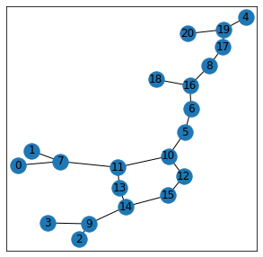

```python
# We just use the first in the list
idx = 0
visualize(G[idx])
```

## Plot the vector representation with KernelPCA

Just by this plot we can already see that there are outliers that might disturb our K-Means assumptions

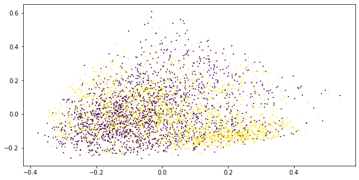

```python
#Gram Matrix for the Weisfeiler-Lehman subtree kernel
iterations = 5
gram = load_csv(os.path.join(base_path,f"{ds_name}_gram_matrix_wl{iterations}.csv"))
gram = aux.normalize_gram_matrix(gram)

kpca = KernelPCA(n_components=100, kernel="precomputed")
reduced_kpca = kpca.fit_transform(gram)
fig, ax = plt.subplots(figsize=(10,5))
ax.scatter(reduced_kpca[:,0], reduced_kpca[:,1], c=classes, s=1)
plt.show();
```

## Plot the vector representation with TruncatedSVD

Also here we can see some outlier points.

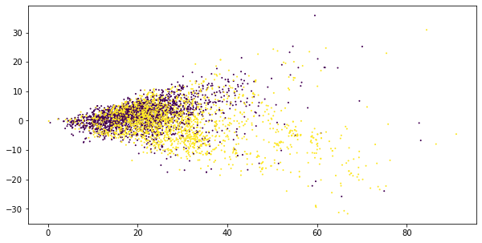

```python
#Gram Matrix for the Weisfeiler-Lehman subtree kernel
iterations = 5
vec = load_sparse(os.path.join(base_path,f"{ds_name}_vectors_wl{iterations}.npz"))
tsvd = TruncatedSVD(n_components=100)
reduced_tsvd = tsvd.fit_transform(vec)

fig, ax = plt.subplots(figsize=(10,5))
ax.scatter(reduced_tsvd[:,0], reduced_tsvd[:,1], c=classes, s=1)
plt.show();
```

## Apply Subkmeans with KernelPCA

```python
k = len(set(classes.tolist()))
print("n_clusters: ", k)
nrkm = NrKmeans(n_clusters=[k,1], allow_larger_noise_space=True)
nrkm.fit(reduced_kpca, best_of_n_rounds=10, verbose=False)
print("Found Cluster Subspaces: ", nrkm.m)
subkm_nmi = normalized_mutual_info_score(nrkm.labels[0],classes)
print(f"Subkmeans NMI:{subkm_nmi:.4f}")
```

```
n_clusters:  2
Found Cluster Subspaces:  [1, 99]
Subkmeans NMI:0.0315
```

**Plot the rotated space**

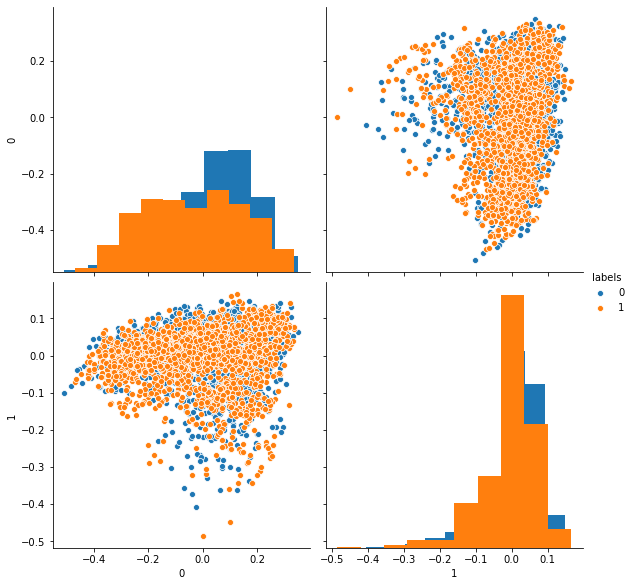

```python
V = nrkm.V
rotated = np.dot(reduced_kpca,V)
reduced_df = pd.DataFrame(rotated[:,0:2])
reduced_df["labels"] = classes
sns.pairplot(reduced_df, hue="labels", diag_kind="hist", height=4)
plt.show();
```

## Cluster Analysis with KMeans

Here we use a simple technique for interpreting our cluster results for the NCI1 data set, but it works the same for the other data sets. We investigate the nearest neighbours of each centroid in each cluster.

```python
# only keep the first 10 components to speed up computation
reduced_kpca_10 = reduced_kpca[:, 0:10]
```

### First we determine the number of k clusters using a scree plot

```python
costs = []
kmeans_runs = []
k_list = [1, 2, 5, 10, 15, 20, 25, 30, 35, 40]
for k in k_list:
    kmeans = KMeans(n_clusters=k)
    kmeans.fit(reduced_kpca_10)
    costs.append(kmeans.inertia_)
    kmeans_runs.append(deepcopy(kmeans))
```

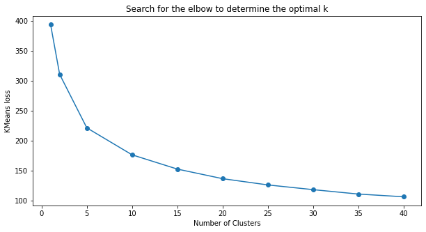

```python
def scree_plot(k_list, costs):
    plt.figure(figsize=(10,5))
    plt.plot(k_list, costs, marker="o")
    plt.xlabel('Number of Clusters')
    plt.ylabel('KMeans loss')
    plt.title('Search for the elbow to determine the optimal k')
    plt.show();
scree_plot(k_list, costs)
```

Choose k=15

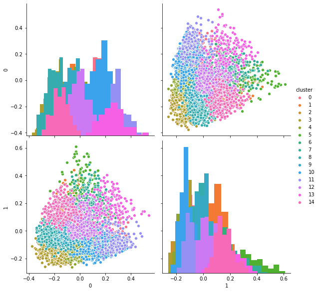

```python
selected_idx = 4
kmeans = kmeans_runs[selected_idx]
df = pd.DataFrame(reduced_kpca_10[:,0:2])
df["cluster"] = kmeans.labels_
sns.pairplot(df, hue="cluster", diag_kind="hist", height=4)
plt.show();
```

## Plot the first n nearest neighbours of each centroid

```python
from sklearn.metrics import pairwise_distances
# select first 2 nearest neighbours in for each cluster
nr_nearest = 2
nearest_indices = []
for cluster_i in set(kmeans.labels_):
    mask = (kmeans.labels_ == cluster_i)
    selection = reduced_kpca_10[mask]
    print(f"number of data points in cluster {cluster_i}: {selection.shape[0]}")
    center_i = kmeans.cluster_centers_[cluster_i].reshape(1,-1)
    distances_i = pairwise_distances(center_i, reduced_kpca_10)
    nearest_indices.append(np.argsort(distances_i, )[0][0:nr_nearest])
    print(f"Nearest data points in cluster {cluster_i}: {nearest_indices[-1]}")
```

```
number of data points in cluster 0: 391
Nearest data points in cluster 0: [1482 2938]
number of data points in cluster 1: 292
Nearest data points in cluster 1: [2381 2883]
number of data points in cluster 2: 141
Nearest data points in cluster 2: [ 977 1446]
number of data points in cluster 3: 384
Nearest data points in cluster 3: [273 233]
number of data points in cluster 4: 406
Nearest data points in cluster 4: [3577 2972]
number of data points in cluster 5: 108
Nearest data points in cluster 5: [617 744]
number of data points in cluster 6: 158
Nearest data points in cluster 6: [3370 2523]
number of data points in cluster 7: 99
Nearest data points in cluster 7: [ 648 1960]
number of data points in cluster 8: 411
Nearest data points in cluster 8: [3470  922]
number of data points in cluster 9: 386
Nearest data points in cluster 9: [3797   94]
number of data points in cluster 10: 411
Nearest data points in cluster 10: [2928 3213]
number of data points in cluster 11: 224
Nearest data points in cluster 11: [2096 1804]
number of data points in cluster 12: 323
Nearest data points in cluster 12: [3461  923]
number of data points in cluster 13: 139
Nearest data points in cluster 13: [1935 2052]
number of data points in cluster 14: 237
Nearest data points in cluster 14: [110 360]
```

```
Cluster 0, Indices [1482 2938]
```

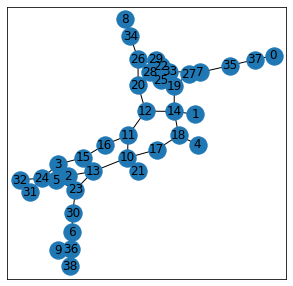

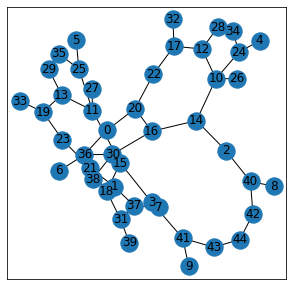

```
Cluster 1, Indices [2381 2883]
```

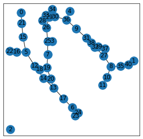

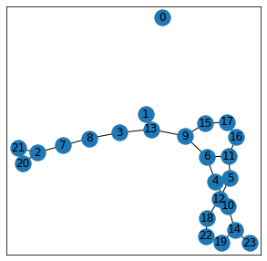

```
Cluster 2, Indices [ 977 1446]
```

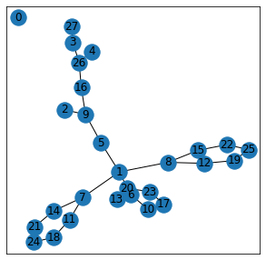

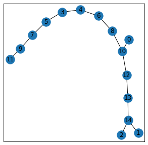

```
Cluster 3, Indices [273 233]
```

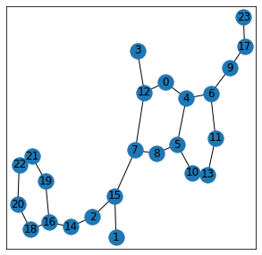

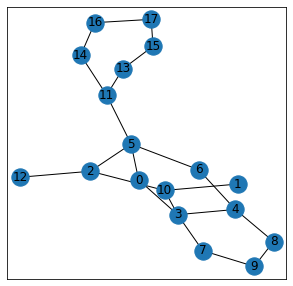

```
Cluster 4, Indices [3577 2972]
```

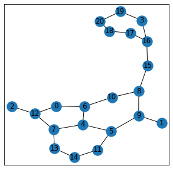

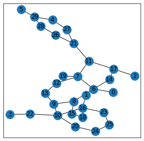

```
Cluster 5, Indices [617 744]
```

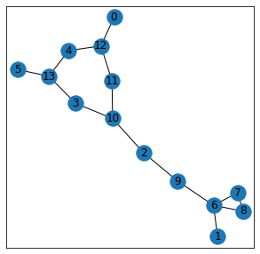

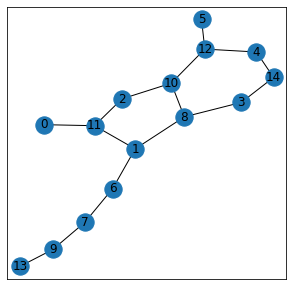

```
Cluster 6, Indices [3370 2523]
```

[18 more figures not shown]

```python
for i, indices in enumerate(nearest_indices):
    print(f"Cluster {i}, Indices {indices}")
    G_selected = select_from_list(G, indices)
    for g_i in G_selected:
        visualize(g_i)
```

## Overview of NMI performance for different representations

### KPCA

Applied [Kernel PCA](https://scikit-learn.org/stable/modules/generated/sklearn.decomposition.KernelPCA.html) with the provided Gram matrix and then clustered the reduced representation with Subkmeans with $k=$'number of ground truth classes'.

### SVD

Applied [Truncated SVD](https://scikit-learn.org/stable/modules/generated/sklearn.decomposition.TruncatedSVD.html) a version of SVD that can handle sparse feature matrices and then clustered the reduced representation with Subkmeans with $k=$'number of ground truth classes'.

### Spectral Clustering

Applied [Spectral Clustering](https://scikit-learn.org/stable/modules/generated/sklearn.cluster.SpectralClustering.html), an algorithm that is often used to cluster graph data, with the similarities provided by the Gram matrices and with $k=$'number of ground truth classes'. In contrast to Subkmeans Spectral Clustering can find arbitrarily shaped clusters.

```
#################node_labels#################
```

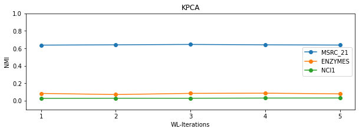

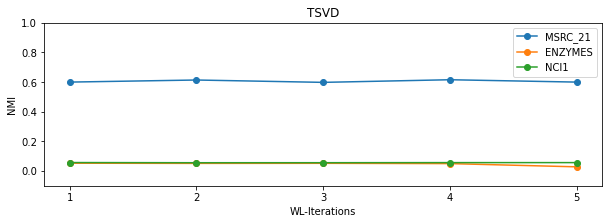

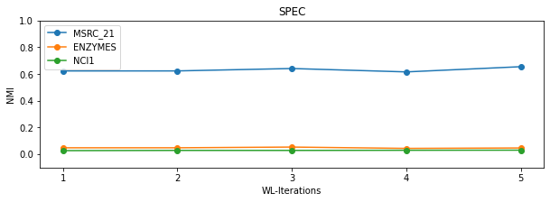

```
#################without_labels#################
```

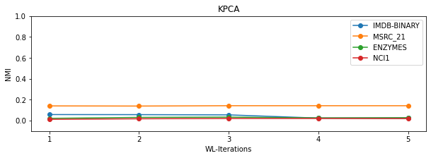

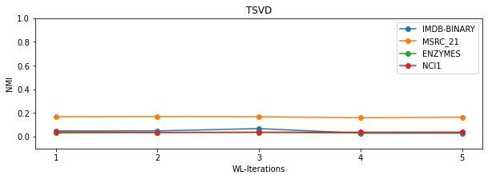

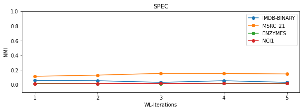

```python
result_names = ["KPCA", "TSVD", "SPEC"]
for version in ["node_labels", "without_labels"]:
    print(f"#################{version}#################")
    for name_i in result_names:
        path_i = os.path.join("kernels", version, name_i+".csv")
        nmi_df = pd.read_csv(path_i, index_col=0)
        fig, ax = plt.subplots(figsize=(10,3))
        ax.set_ylabel("NMI")
        ax.set_xlabel("WL-Iterations")
        ax.set_ylim([-0.1,1])
        ax.set_xticks([0,1,2,3,4])
        ax.set_xticklabels([1,2,3,4,5])
        ax.set_title(name_i)
        nmi_df.plot(marker="o", ax=ax)
        plt.show();
```